# MSRR CH02, Sections 1-3 HW

SOLUTIONS / Jill E. Thomley

Updated: Monday, February 18, 2019 @ 04:09:19 PM

**Instructions**

Complete the following problems from *Mathematical Statistics with Resampling and R*. You can access the textbook datasets on our [Class Data Files](https://stat-jet-asu.github.io/Datasets/DatasetList.html) page or from the `R` package `resampledata`. The textbook examples use base `R`code for plotting, but you `ggplot2` for visualizations. You may use `table()` to make tables, but you should use `dplyr` for other summaries. Refer to the case studies in Chapter 1 to add informative titles and axis labels to your plots and to provide context for your answers.

Load the packages and datasets you need here.

```r
library(dplyr)
library(ggplot2)
library(resampledata)
```

#### Problem 2.1

Note: Test for equality using code, not just visual inspection.

```r
# basic solution
data    <- c(3, 5, 8, 15, 20, 21)
logdata <- log(data)
xbar_data <- mean(data)
med_data  <- median(data)
xbar_logdata <- mean(logdata)
med_logdata  <- median(logdata)
log(xbar_data) == xbar_logdata
```

```
[1] FALSE
```

```r
log(med_data) == median(logdata)
```

```
[1] FALSE
```

```r
# solution using dplyr
summary1 <- tibble(data = c(3, 5, 8, 15, 20, 21)) %>%
  mutate(logdata = log(data)) %>%
  summarize(xbar_data         = mean(data),
            med_data          = median(data),
            xbar_logdata      = mean(logdata),
            med_logdata       = median(logdata),
            test_equal_mean   = log(xbar_data) == xbar_logdata,
            test_equal_median = log(med_data) == median(logdata))
glimpse(summary1)   # using glimpse because of long variable names
```

```
Observations: 1
Variables: 6
$ xbar_data         <dbl> 12
$ med_data          <dbl> 11.5
$ xbar_logdata      <dbl> 2.255966
$ med_logdata       <dbl> 2.393746
$ test_equal_mean   <lgl> FALSE
$ test_equal_median <lgl> FALSE
```

Nonlinear transformations alter proportional spacing of data on the number line, so f(statistic(x)) is not equal to statistic(f(x)).

#### Problem 2.2

Note: Test for equality using code, not just visual inspection.

```r
data     <- c(1, 2, 4, 5, 6, 8, 11, 15)
sqrtdata <- sqrt(data)
xbar_data <- mean(data)
med_data  <- median(data)
xbar_sqrtdata <- mean(sqrtdata)
med_sqrtdata  <- median(sqrtdata)
log(xbar_data) == xbar_sqrtdata
```

```
[1] FALSE
```

```r
log(med_data) == median(sqrtdata)
```

```
[1] FALSE
```

```r
# solution using dplyr
summary2 <- tibble(data = c(1, 2, 4, 5, 6, 8, 11, 15)) %>%
  mutate(sqrtdata = sqrt(data)) %>%
  summarize(xbar_data         = mean(data),
            med_data          = median(data),
            xbar_sqrtdata     = mean(sqrtdata),
            med_sqrtdata      = median(sqrtdata),
            test_equal_mean   = sqrt(xbar_data) == xbar_sqrtdata,
            test_equal_median = sqrt(med_data) == median(sqrtdata))
glimpse(summary2)   # using glimpse because of long variable names
```

```
Observations: 1
Variables: 6
$ xbar_data         <dbl> 6.5
$ med_data          <dbl> 5.5
$ xbar_sqrtdata     <dbl> 2.389726
$ med_sqrtdata      <dbl> 2.342779
$ test_equal_mean   <lgl> FALSE
$ test_equal_median <lgl> FALSE
```

Nonlinear transformations alter proportional spacing of data on the number line, so f(statistic(x)) is not equal to statistic(f(x)).

#### Problem 2.5

Note: In (c), create the table of proportions you need to answer (d) as well as a table of counts.

Part (a)

```r
# using base
table(GSS2002$DeathPenalty)
```

```
 Favor Oppose
   899    409
```

```r
# using dplyr
GSS2002 %>% count(DeathPenalty)
```

```
# A tibble: 3 x 2
  DeathPenalty     n
  <fct>        <int>
1 Favor          899
2 Oppose         409
3 <NA>          1457
```

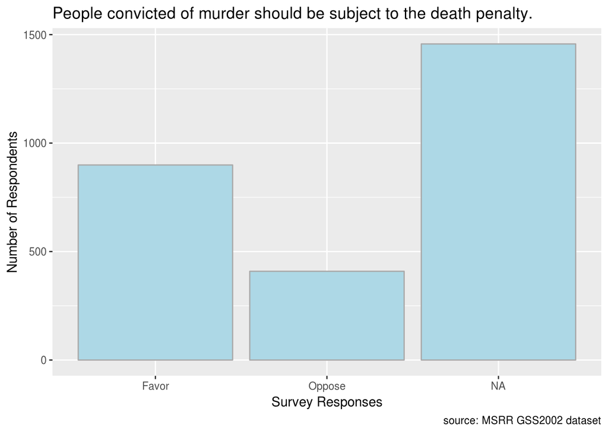

```r
ggplot(GSS2002, aes(DeathPenalty)) +
  geom_bar(fill = "lightblue", color = "darkgray") +
  labs(title = "People convicted of murder should be subject to the death penalty.",
       caption = "source: MSRR GSS2002 dataset",
       x = "Survey Responses",
       y = "Number of Respondents")
```

Part (b)

```r
table(GSS2002$OwnGun)
```

```
     No Refused     Yes
    605       9     310
```

```r
summary(GSS2002$OwnGun)
```

```
     No Refused     Yes    NA's
    605       9     310    1841
```

ANSWER: The summary shows the NA values while the table does not.

Part (c)

```r
table(GSS2002$OwnGun, GSS2002$DeathPenalty)
```

```
          Favor Oppose
  No        375    199
  Refused     7      2
  Yes       243     59
```

```r
prop.table(table(GSS2002$OwnGun, GSS2002$DeathPenalty), 1)
```

```
              Favor    Oppose
  No      0.6533101 0.3466899
  Refused 0.7777778 0.2222222
  Yes     0.8046358 0.1953642
```

Part (d)

ANSWER: They appear different. About 80% of gun owners favor the death penalty versus about 65% of non gun owners.

#### Problem 2.6

Note: In (b), create a table of proportions as well as a table of counts to answer the question. In (c), also compute the upper fence for each group to show the upper cutoff for outliers.

Part (a)

```r
# using base
table(Recidivism$Recid)
```

```
   No   Yes
11636  5386
```

```r
# using dplyr
Recidivism %>% count(Recid)
```

```
# A tibble: 2 x 2
  Recid     n
  <fct> <int>
1 No    11636
2 Yes    5386
```

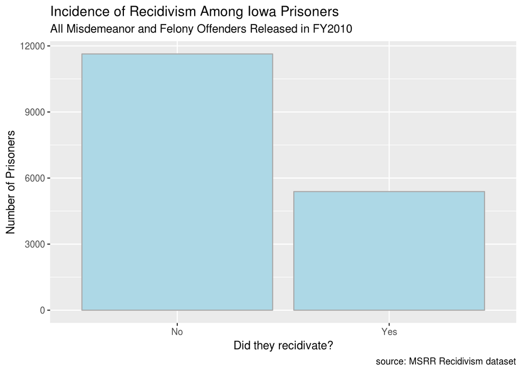

```r
ggplot(Recidivism, aes(Recid)) +
  geom_bar(fill = "lightblue", color = "darkgray") +
  labs(title = "Incidence of Recidivism Among Iowa Prisoners",
       subtitle = "All Misdemeanor and Felony Offenders Released in FY2010",
       caption = "source: MSRR Recidivism dataset",
       x = "Did they recidivate?",
       y = "Number of Prisoners")
```

Part (b)

```r
# using base
table(Recidivism$Age25, Recidivism$Recid)
```

```
             No  Yes
  Under 25 1954 1123
  Over 25  9679 4263
```

```r
prop.table(table(Recidivism$Age25, Recidivism$Recid), 1)
```

```
                  No       Yes
  Under 25 0.6350341 0.3649659
  Over 25  0.6942333 0.3057667
```

```r
# using dplyr
Recidivism %>%
  filter(complete.cases(Age25)) %>%
  count(Recid, Age25)
```

```
# A tibble: 4 x 3
  Recid Age25        n
  <fct> <fct>    <int>
1 No    Under 25  1954
2 No    Over 25   9679
3 Yes   Under 25  1123
4 Yes   Over 25   4263
```

```r
Recidivism %>%
  filter(complete.cases(Age25)) %>%
  group_by(Age25) %>%
  summarize(prop_yes = mean(Recid == "Yes"))
```

```
# A tibble: 2 x 2
  Age25    prop_yes
  <fct>       <dbl>
1 Under 25    0.365
2 Over 25     0.306
```

Part (c)

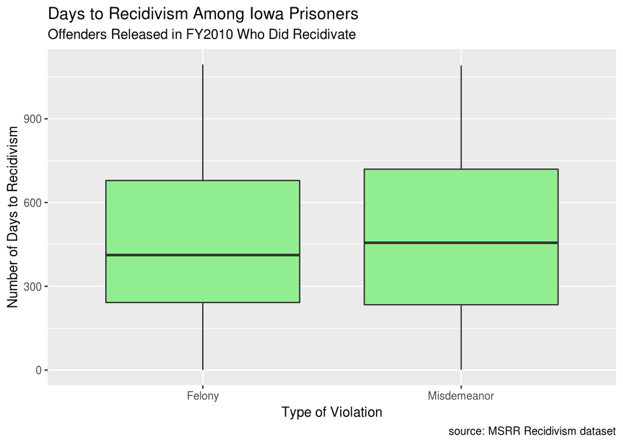

```r
ggplot(Recidivism, aes(x = Offense, y = Days)) +
  geom_boxplot(fill = "lightgreen") +
  labs(title = "Days to Recidivism Among Iowa Prisoners",
       subtitle = "Offenders Released in FY2010 Who Did Recidivate",
       caption = "source: MSRR Recidivism dataset",
       x = "Type of Violation",
       y = "Number of Days to Recidivism")
```

Comparison 1: The groups seem to have similar minimums, Q1, and maximum values.

Comparison 2: The median is the misdemeanor group seems to be slightly larger.

Comparison 3: There are no outliers in either group.

Overall, the distributions appear to be similar in shape, center, and spread.

Part (d)

```r
# using base
quantile(Recidivism$Days, c(0.25, 0.50, 0.75), na.rm = TRUE)
```

```
25% 50% 75%
241 418 687
```

```r
# using dplyr
Recidivism %>%
  summarize(Q1  = quantile(Days, 0.25, na.rm = TRUE),
            Med = quantile(Days, 0.50, na.rm = TRUE),
            Q3  = quantile(Days, 0.75, na.rm = TRUE))
```

```
   Q1 Med  Q3
1 241 418 687
```

```r
# extra, by groups to go with boxplot
Recidivism %>%
  filter(complete.cases(Age25)) %>%
  group_by(Age25) %>%
  summarize(Q1  = quantile(Days, 0.25, na.rm = TRUE),
            Med = quantile(Days, 0.50, na.rm = TRUE),
            Q3  = quantile(Days, 0.75, na.rm = TRUE))
```

```
# A tibble: 2 x 4
  Age25       Q1   Med    Q3
  <fct>    <dbl> <dbl> <dbl>
1 Under 25  212.   384   656
2 Over 25   250    428   695
```

Part (e)

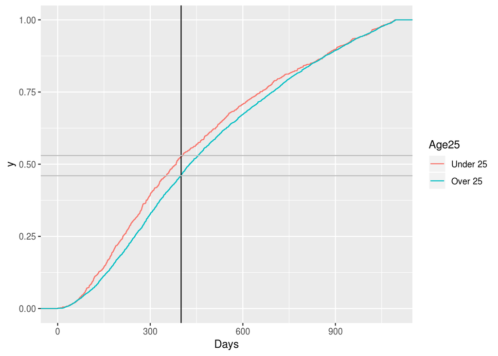

```r
Recidivism %>%
  filter(complete.cases(Age25)) %>%
  ggplot(aes(x = Days, color = Age25)) +
  stat_ecdf() +
  geom_vline(xintercept = 400) +
  geom_hline(yintercept = c(.46, .53), color = "gray")   # eyeball estimates of intersections
```

ANSWER: Of those who recidivated, about 53% of those under 25 did so on or before 400 days, versus about 46% of those 25 and over. (The variable label says “Over 25” but the description in Chapter 1 states that the group is actually 25 and over.)